# eda

Xue Zhang

2023-12-10

```r
library(gtsummary)
library(tidyverse)
library(car)
library(caret)
```

```r
library(corrplot)
library(gridExtra)
library(MASS)
library(purrr)

knitr::opts_chunk$set(
    echo = TRUE,
    warning = FALSE,
    fig.width = 8,
  fig.height = 6,
  out.width = "90%"
)

options(
  ggplot2.continuous.colour = "viridis",
  ggplot2.continuous.fill = "viridis"
)

scale_colour_discrete = scale_colour_viridis_d
scale_fill_discrete = scale_fill_viridis_d

theme_set(theme_minimal() + theme(legend.position = "bottom"))
```

```r
data = read_csv("./data/data.csv") |>
  janitor::clean_names()
summary(data)
```

```
##       age            race           marital_status       t_stage
##  Min.   :30.00   Length:4024        Length:4024        Length:4024
##  1st Qu.:47.00   Class :character   Class :character   Class :character
##  Median :54.00   Mode  :character   Mode  :character   Mode  :character
##  Mean   :53.97
##  3rd Qu.:61.00
##  Max.   :69.00
##    n_stage           x6th_stage        differentiate         grade
##  Length:4024        Length:4024        Length:4024        Length:4024
##  Class :character   Class :character   Class :character   Class :character
##  Mode  :character   Mode  :character   Mode  :character   Mode  :character
##
##
##
##    a_stage            tumor_size     estrogen_status    progesterone_status
##  Length:4024        Min.   :  1.00   Length:4024        Length:4024
##  Class :character   1st Qu.: 16.00   Class :character   Class :character
##  Mode  :character   Median : 25.00   Mode  :character   Mode  :character
##                     Mean   : 30.47
##                     3rd Qu.: 38.00
##                     Max.   :140.00
##  regional_node_examined reginol_node_positive survival_months
##  Min.   : 1.00          Min.   : 1.000        Min.   :  1.0
##  1st Qu.: 9.00          1st Qu.: 1.000        1st Qu.: 56.0
##  Median :14.00          Median : 2.000        Median : 73.0
##  Mean   :14.36          Mean   : 4.158        Mean   : 71.3
##  3rd Qu.:19.00          3rd Qu.: 5.000        3rd Qu.: 90.0
##  Max.   :61.00          Max.   :46.000        Max.   :107.0
##     status
##  Length:4024
##  Class :character
##  Mode  :character
##
##
##
```

```r
str(data)
```

```
## spc_tbl_ [4,024 × 16] (S3: spec_tbl_df/tbl_df/tbl/data.frame)
##  $ age                   : num [1:4024] 68 50 58 58 47 51 51 40 40 69 ...
##  $ race                  : chr [1:4024] "White" "White" "White" "White" ...
##  $ marital_status        : chr [1:4024] "Married" "Married" "Divorced" "Married" ...
##  $ t_stage               : chr [1:4024] "T1" "T2" "T3" "T1" ...
##  $ n_stage               : chr [1:4024] "N1" "N2" "N3" "N1" ...
##  $ x6th_stage            : chr [1:4024] "IIA" "IIIA" "IIIC" "IIA" ...
##  $ differentiate         : chr [1:4024] "Poorly differentiated" "Moderately differentiated" "Moderately differentiated" "Poorly differentiated" ...
##  $ grade                 : chr [1:4024] "3" "2" "2" "3" ...
##  $ a_stage               : chr [1:4024] "Regional" "Regional" "Regional" "Regional" ...
##  $ tumor_size            : num [1:4024] 4 35 63 18 41 20 8 30 103 32 ...
##  $ estrogen_status       : chr [1:4024] "Positive" "Positive" "Positive" "Positive" ...
##  $ progesterone_status   : chr [1:4024] "Positive" "Positive" "Positive" "Positive" ...
##  $ regional_node_examined: num [1:4024] 24 14 14 2 3 18 11 9 20 21 ...
##  $ reginol_node_positive : num [1:4024] 1 5 7 1 1 2 1 1 18 12 ...
##  $ survival_months       : num [1:4024] 60 62 75 84 50 89 54 14 70 92 ...
##  $ status                : chr [1:4024] "Alive" "Alive" "Alive" "Alive" ...
##  - attr(*, "spec")=
##   .. cols(
##   ..   Age = col_double(),
##   ..   Race = col_character(),
##   ..   `Marital Status` = col_character(),
##   ..   `T Stage` = col_character(),
##   ..   `N Stage` = col_character(),
##   ..   `6th Stage` = col_character(),
##   ..   differentiate = col_character(),
##   ..   Grade = col_character(),
##   ..   `A Stage` = col_character(),
##   ..   `Tumor Size` = col_double(),
##   ..   `Estrogen Status` = col_character(),
##   ..   `Progesterone Status` = col_character(),
##   ..   `Regional Node Examined` = col_double(),
##   ..   `Reginol Node Positive` = col_double(),
##   ..   `Survival Months` = col_double(),
##   ..   Status = col_character()
##   .. )
##  - attr(*, "problems")=<externalptr>
```

```r
# Check for missing data
colSums(is.na(data))
```

```
##                    age                   race         marital_status
##                      0                      0                      0
##                t_stage                n_stage             x6th_stage
##                      0                      0                      0
##          differentiate                  grade                a_stage
##                      0                      0                      0
##             tumor_size        estrogen_status    progesterone_status
##                      0                      0                      0
## regional_node_examined  reginol_node_positive        survival_months
##                      0                      0                      0
##                 status
##                      0
```

```r
# Convert character to factor for regression analysis
clean_data = data |>
  mutate(
    race = as.numeric(factor(race, levels = c("White", "Black", "Other"))) - 1,
    marital_status = as.numeric(factor(marital_status, levels = c("Married", "Single", "Divorced", "Widowed", "Separated"))) - 1,
    t_stage = as.numeric(factor(t_stage, levels = c("T1", "T2", "T3", "T4"))) - 1,
    n_stage = as.numeric(factor(n_stage, levels = c("N1", "N2", "N3"))) - 1,
    x6th_stage = as.numeric(factor(x6th_stage, levels = c("IIA", "IIB", "IIIA", "IIIB", "IIIC"))) - 1,
    differentiate = as.numeric(factor(differentiate, levels = c("Undifferentiated", "Poorly differentiated", "Moderately differentiated", "Well differentiated"))) - 1,
    grade = as.numeric(factor(grade, levels = c("1", "2", "3", "anaplastic; Grade IV"))),
    a_stage = as.numeric(factor(a_stage, levels = c("Regional", "Distant"))) - 1,
    estrogen_status = as.numeric(factor(estrogen_status, levels = c("Negative", "Positive"))) - 1,
    progesterone_status = as.numeric(factor(progesterone_status, levels = c("Negative", "Positive"))) - 1,
    status = as.numeric(factor(status, levels = c("Dead", "Alive"))) - 1)|>
  rename(regional_node_positive = reginol_node_positive)

summary(clean_data)
```

```
##       age             race        marital_status      t_stage
##  Min.   :30.00   Min.   :0.0000   Min.   :0.0000   Min.   :0.0000
##  1st Qu.:47.00   1st Qu.:0.0000   1st Qu.:0.0000   1st Qu.:0.0000
##  Median :54.00   Median :0.0000   Median :0.0000   Median :1.0000
##  Mean   :53.97   Mean   :0.2314   Mean   :0.6143   Mean   :0.7848
##  3rd Qu.:61.00   3rd Qu.:0.0000   3rd Qu.:1.0000   3rd Qu.:1.0000
##  Max.   :69.00   Max.   :2.0000   Max.   :4.0000   Max.   :3.0000
##     n_stage         x6th_stage    differentiate       grade
##  Min.   :0.0000   Min.   :0.000   Min.   :0.000   Min.   :1.000
##  1st Qu.:0.0000   1st Qu.:0.000   1st Qu.:1.000   1st Qu.:2.000
##  Median :0.0000   Median :1.000   Median :2.000   Median :2.000
##  Mean   :0.4384   Mean   :1.322   Mean   :1.849   Mean   :2.151
##  3rd Qu.:1.0000   3rd Qu.:2.000   3rd Qu.:2.000   3rd Qu.:3.000
##  Max.   :2.0000   Max.   :4.000   Max.   :3.000   Max.   :4.000
##     a_stage          tumor_size     estrogen_status  progesterone_status
##  Min.   :0.00000   Min.   :  1.00   Min.   :0.0000   Min.   :0.0000
##  1st Qu.:0.00000   1st Qu.: 16.00   1st Qu.:1.0000   1st Qu.:1.0000
##  Median :0.00000   Median : 25.00   Median :1.0000   Median :1.0000
##  Mean   :0.02286   Mean   : 30.47   Mean   :0.9332   Mean   :0.8265
##  3rd Qu.:0.00000   3rd Qu.: 38.00   3rd Qu.:1.0000   3rd Qu.:1.0000
##  Max.   :1.00000   Max.   :140.00   Max.   :1.0000   Max.   :1.0000
##  regional_node_examined regional_node_positive survival_months     status
##  Min.   : 1.00          Min.   : 1.000         Min.   :  1.0   Min.   :0.0000
##  1st Qu.: 9.00          1st Qu.: 1.000         1st Qu.: 56.0   1st Qu.:1.0000
##  Median :14.00          Median : 2.000         Median : 73.0   Median :1.0000
##  Mean   :14.36          Mean   : 4.158         Mean   : 71.3   Mean   :0.8469
##  3rd Qu.:19.00          3rd Qu.: 5.000         3rd Qu.: 90.0   3rd Qu.:1.0000
##  Max.   :61.00          Max.   :46.000         Max.   :107.0   Max.   :1.0000
```

```r
str(clean_data)
```

```
## tibble [4,024 × 16] (S3: tbl_df/tbl/data.frame)
##  $ age                   : num [1:4024] 68 50 58 58 47 51 51 40 40 69 ...
##  $ race                  : num [1:4024] 0 0 0 0 0 0 0 0 0 0 ...
##  $ marital_status        : num [1:4024] 0 0 2 0 0 1 0 0 2 0 ...
##  $ t_stage               : num [1:4024] 0 1 2 0 1 0 0 1 3 3 ...
##  $ n_stage               : num [1:4024] 0 1 2 0 0 0 0 0 2 2 ...
##  $ x6th_stage            : num [1:4024] 0 2 4 0 1 0 0 1 4 4 ...
##  $ differentiate         : num [1:4024] 1 2 2 1 1 2 3 2 1 3 ...
##  $ grade                 : num [1:4024] 3 2 2 3 3 2 1 2 3 1 ...
##  $ a_stage               : num [1:4024] 0 0 0 0 0 0 0 0 0 1 ...
##  $ tumor_size            : num [1:4024] 4 35 63 18 41 20 8 30 103 32 ...
##  $ estrogen_status       : num [1:4024] 1 1 1 1 1 1 1 1 1 1 ...
##  $ progesterone_status   : num [1:4024] 1 1 1 1 1 1 1 1 1 1 ...
##  $ regional_node_examined: num [1:4024] 24 14 14 2 3 18 11 9 20 21 ...
##  $ regional_node_positive: num [1:4024] 1 5 7 1 1 2 1 1 18 12 ...
##  $ survival_months       : num [1:4024] 60 62 75 84 50 89 54 14 70 92 ...
##  $ status                : num [1:4024] 1 1 1 1 1 1 1 0 1 1 ...
```

```r
colSums(is.na(clean_data))
```

```
##                    age                   race         marital_status
##                      0                      0                      0
##                t_stage                n_stage             x6th_stage
##                      0                      0                      0
##          differentiate                  grade                a_stage
##                      0                      0                      0
##             tumor_size        estrogen_status    progesterone_status
##                      0                      0                      0
## regional_node_examined regional_node_positive        survival_months
##                      0                      0                      0
##                 status
##                      0
```

```r
write.csv(clean_data, file = "./data/clean_data.csv")
```

# Use `windows` for windows system / `quartz` for macos system

# Use `quartz(width = 12, height = 12)` to open the window

# Use `dev.off()` to close the window

```r
if (!dir.exists("plots")) {
    dir.create("plots")
}

png("plots/pairs_plot.png",
    width = 12 * 600,
    height = 12 * 600,
    res = 600)

pairs(clean_data)
```

# Corr plot

```r
png("plots/corr_plot.png",
    width = 12 * 600,
    height = 12 * 600,
    res = 600)

corrplot(cor(clean_data), type = "upper", diag = FALSE)
```

# Plotting boxplot

```r
plot_boxplot = function(data_vector, main_title, x_label = "") {
  boxplot(data_vector,
          main = main_title,
          xlab = x_label,
          col = "lightblue")
}

png("plots/box_plot.png",
    width = 12 * 600,
    height = 12 * 600,
    res = 600)

par(mar = c(2, 2, 2, 2))
par(mfrow = c(4, 4))


column_names = names(clean_data)
for (col_name in column_names) {
  plot_boxplot(clean_data[[col_name]],
               main_title = col_name,
               x_label = col_name)
}


dev.off()
```

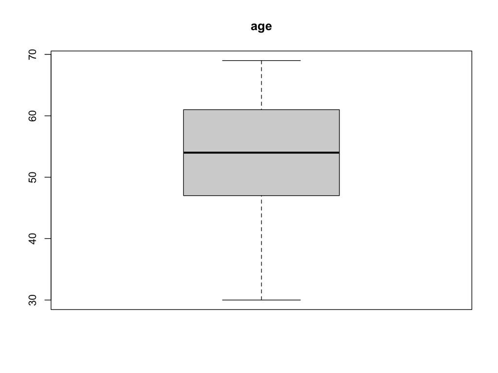

```r
boxplot(clean_data$age, main = "age")
```

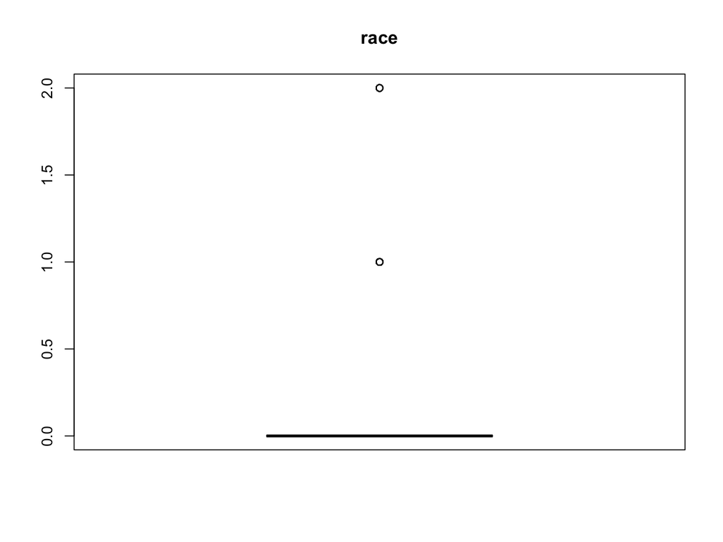

```r
boxplot(clean_data$race, main = "race")
```

2. Race: The race box plot indicates that the majority of the dataset’s observations fall into one category, with a few outliers in the higher categories. Given that race is a categorical variable, it does not require a numerical transformation.

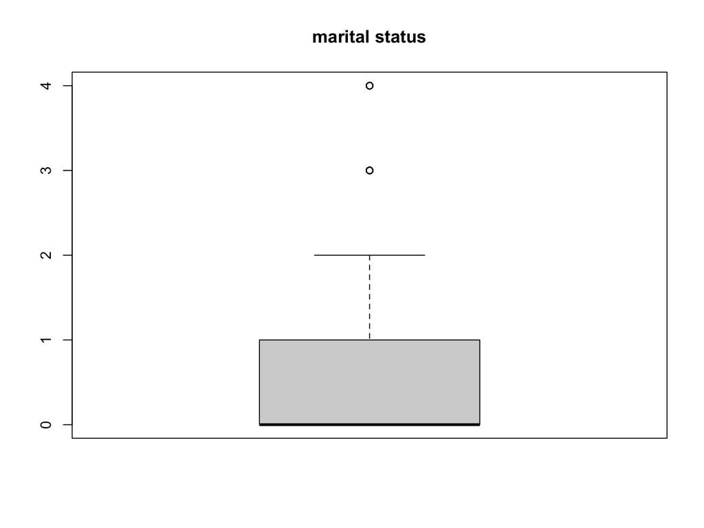

```r
boxplot(clean_data$marital_status, main = "marital status")
```

3. Marital Status: The box plot for marital status shows a concentration of data in the lower categories with some outliers present in the higher categories, it does not require a numerical transformation.

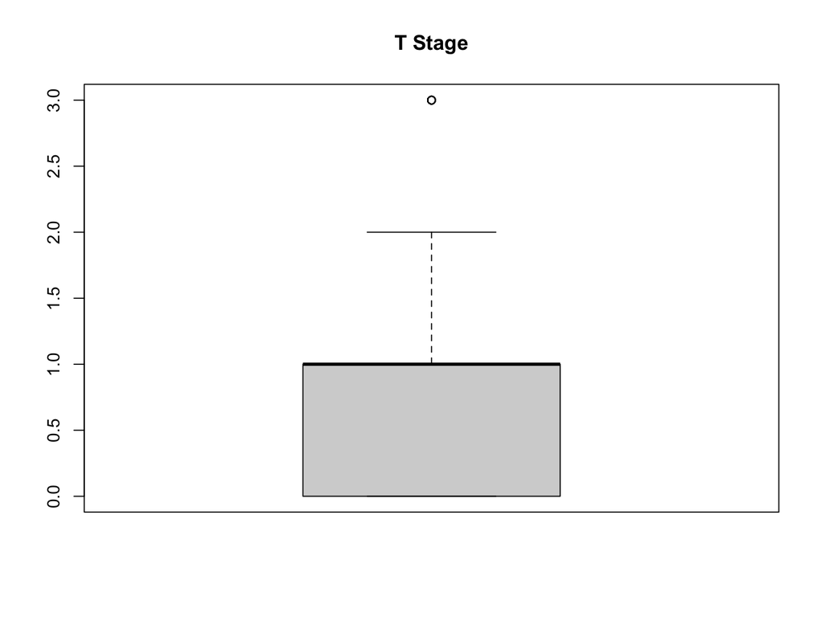

```r
boxplot(clean_data$t_stage, main = "T Stage")
```

4. T Stage: The boxplot for T Stage suggests that most patients are in the early stages (0 and 1), with fewer patients in more advanced stages (2 and 3), as indicated by the median and interquartile range. There are outliers in stage 3, which might represent more severe cases. T Stage is an ordinal variable, representing the size and extent of the main tumor, and does not typically require numerical transformation.

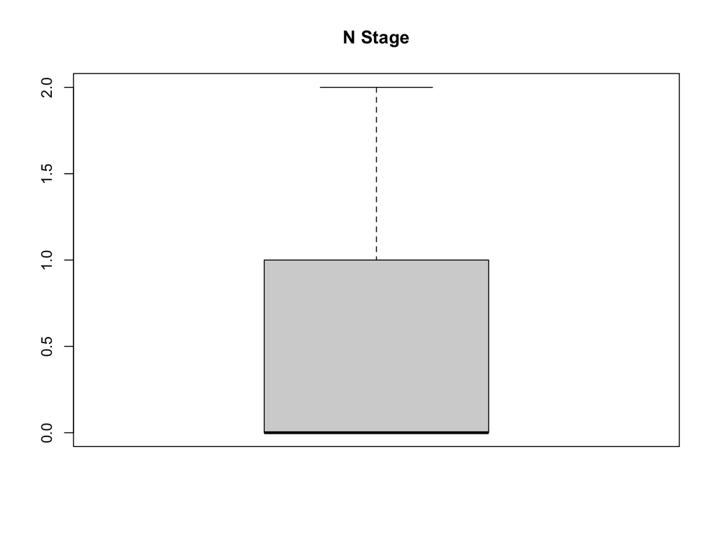

```r
boxplot(clean_data$n_stage, main = "N Stage")
```

5. N Stage: The boxplot for N Stage indicates a distribution that is skewed towards the lower stages, with most data points falling in stage 0 or 1, and fewer in stage 2. There are no outliers, and the spread of the data suggests that most patients have no or minimal regional lymph node involvement.

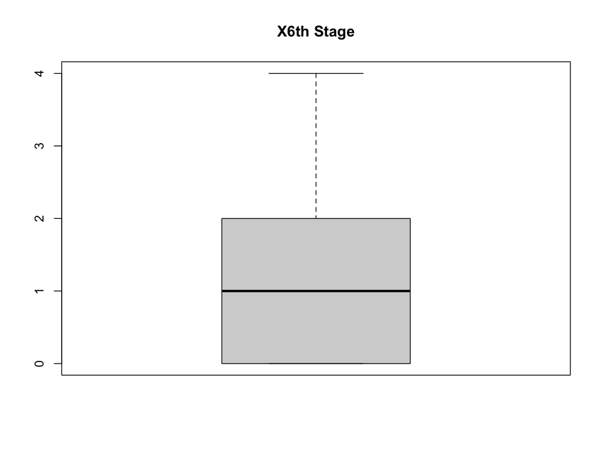

```r
boxplot(clean_data$x6th_stage, main = "X6th Stage")
```

6. X6th Stage: The box plot for the x6th stage shows a relatively even distribution across the stags with the median at stage 1, indicating a moderate level of spread to distant parts of the body. The data points are well-contained within the whiskers, suggesting there are no outliers and no extreme values that would require transformation.

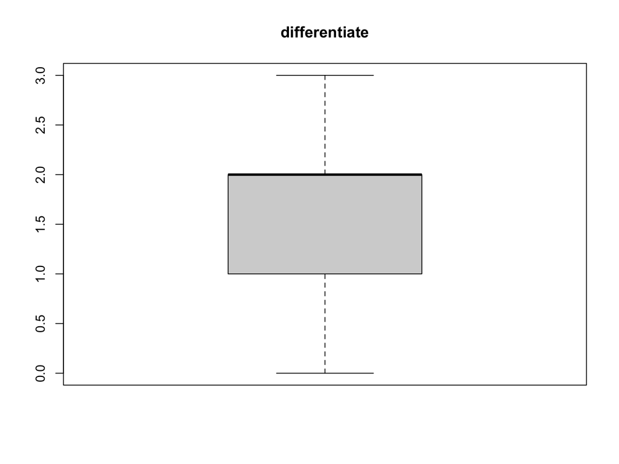

```r
boxplot(clean_data$differentiate, main = "differentiate")
```

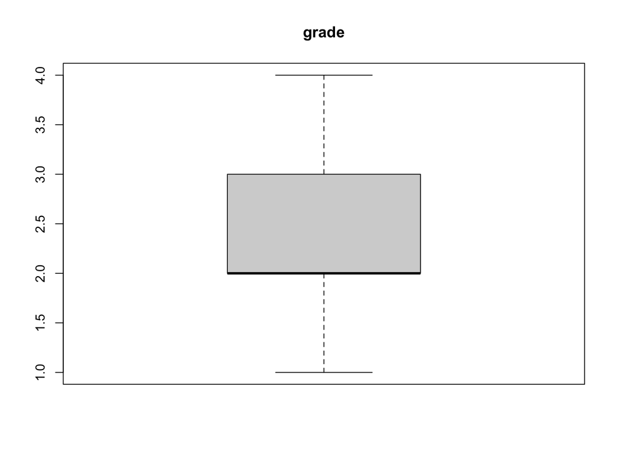

```r
boxplot(clean_data$grade, main = "grade")
```

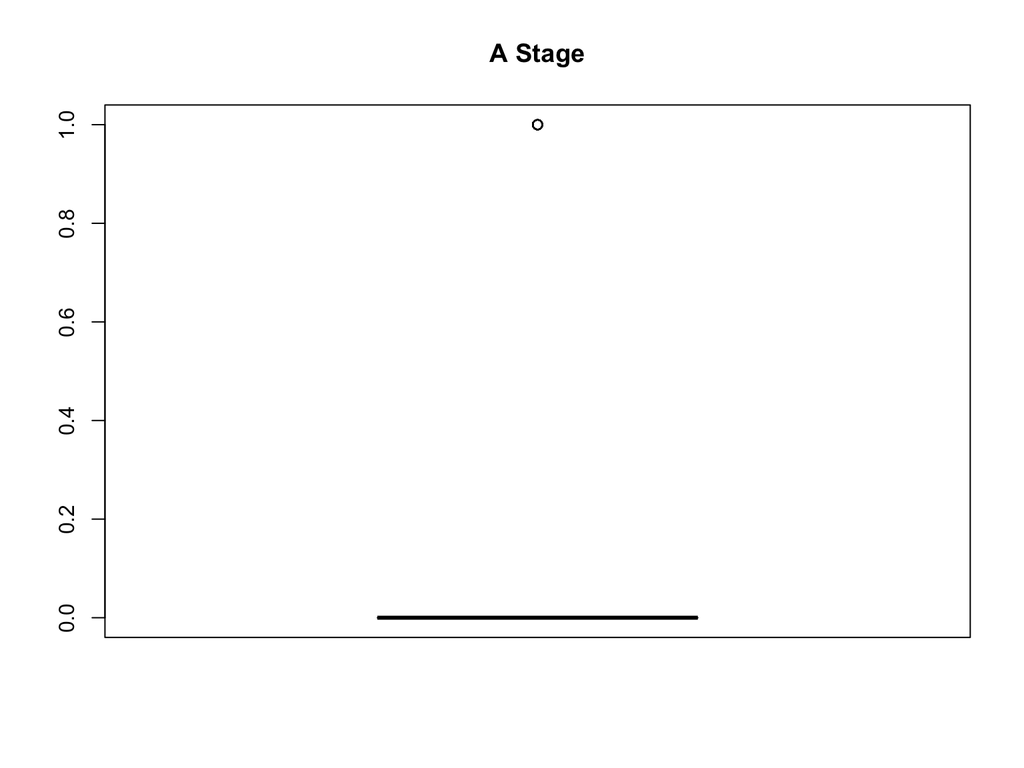

```r
boxplot(clean_data$a_stage, main = "A Stage")
```

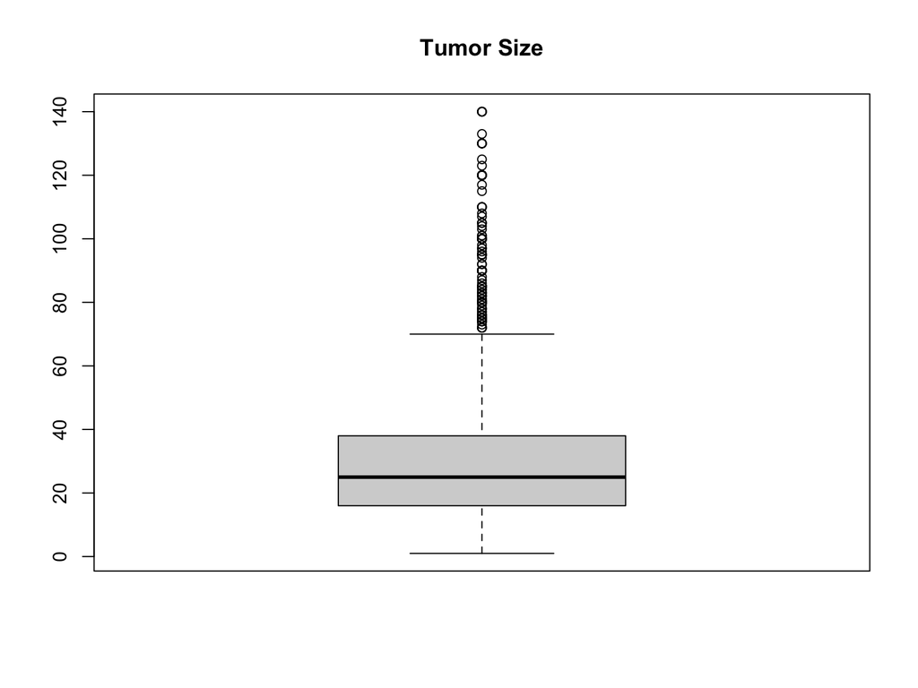

```r
boxplot(clean_data$tumor_size, main = "Tumor Size")
```

10. Tumor Size: The box plot for ‘Tumor Size’ shows a wide range of sizes, with a concentration of smaller tumors and several outliers indicating much larger tumors. The distribution appears right-skewed due to these outliers. Given the skewness and presence of outliers, a transformation such as a logarithmic scale could be beneficial to normalize the data, which may be especially useful if ‘Tumor Size’ is used as a predictor in regression analysis.

# Tumor Size Transformation

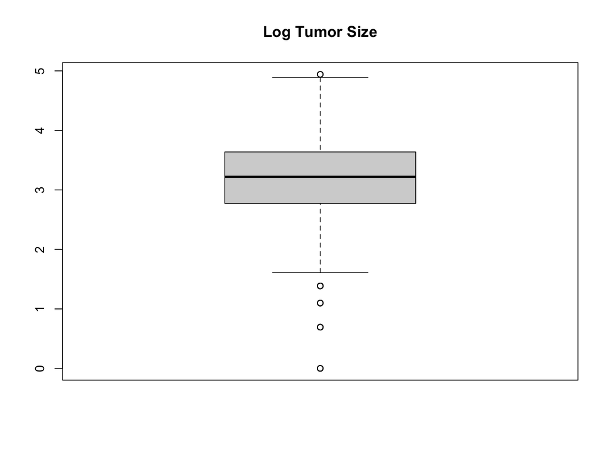

```r
new_data = clean_data|>
  mutate(log_tumor_size = log(tumor_size + 0.001))

boxplot(new_data$log_tumor_size, main = "Log Tumor Size")
```

**The box plot for the log-transformed tumor size shows a distribution that appears more symmetrical and less skewed compared to the original tumor size data. There are still a few outliers present, but overall, the log transformation has normalized the data, as indicated by the more centralized box and shorter whiskers.**

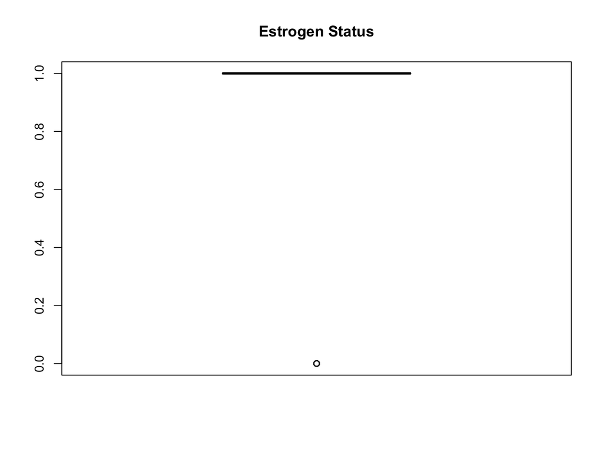

```r
boxplot(clean_data$estrogen_status, main = "Estrogen Status")
```

11. Estrogen Status: The box plot for Estrogen Status suggests that it is a binary categorical variable, likely indicating the presence (1) or absence (0) of estrogen receptors in tumor samples. The plot shows that a large majority of the tumors are positive for estrogen receptors, with very few negative cases, as indicated by the outlier point at zero. As a binary variable, Estrogen Status does not require a numerical transformation for analysis.

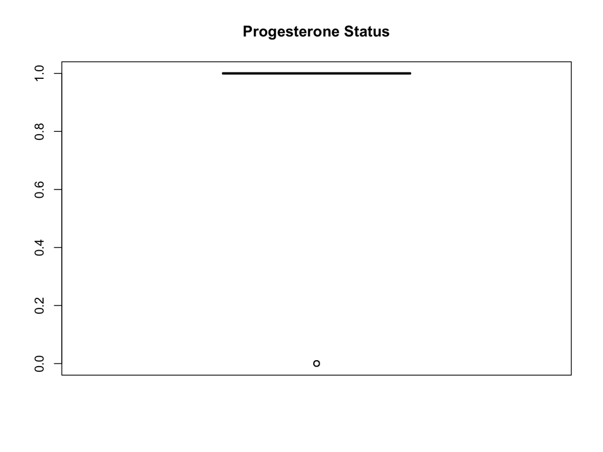

```r
boxplot(clean_data$progesterone_status, main = "Progesterone Status")
```

12. Progesterone Status: The box plot for Progesterone Status indicates that it is also a binary categorical variable, representing the presence (1) or absence (0) of progesterone receptors. Similar to the Estrogen Status, the vast majority of the data points indicate a positive status for progesterone receptors, with the outlier at zero representing the few negative cases. No transformation is needed for this type of categorical data.

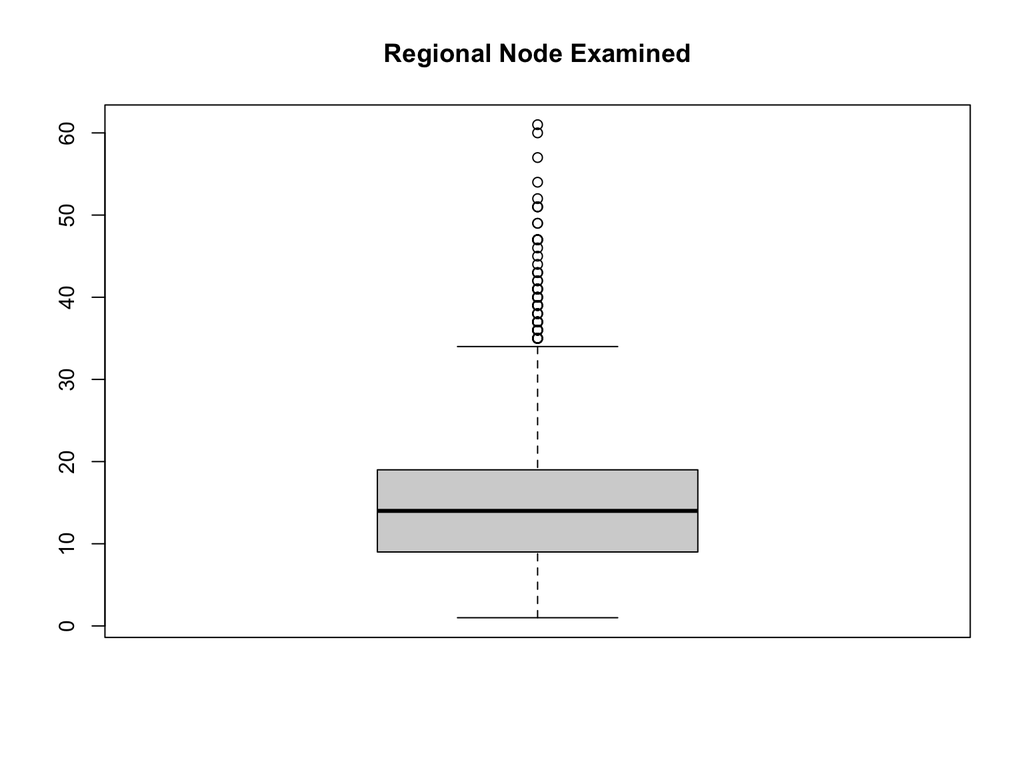

```r
boxplot(clean_data$regional_node_examined, main = "Regional Node Examined")
```

13. Regional Node Examined: The box plot for ‘Regional Node Examined’ displays a right-skewed distribution with a significant number of outliers on the higher end, indicating that while most patients had a smaller number of nodes examined, there are some patients with a much larger number. Given the skewness and presence of outliers, a log transformation might be appropriate to normalize the distribution, especially if this variable is to be used in parametric statistical analyses that assume normality.

# Regional Node Examined Transformation

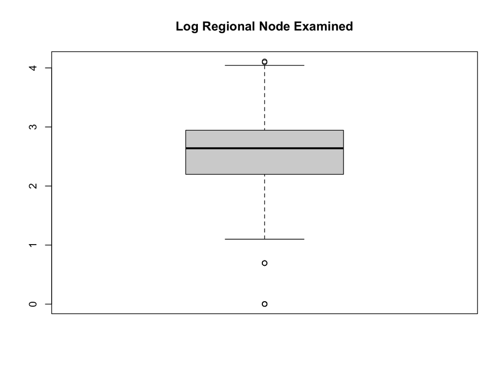

```r
new_data = clean_data|>
  mutate(log_regional_node_examined = log(regional_node_examined + 0.001))

boxplot(new_data$log_regional_node_examined, main = "Log Regional Node Examined")
```

**The box plot for the log-transformed ‘Regional Node Examined’ shows a more symmetrical distribution around the median, with fewer and less extreme outliers than the original data. This indicates that the log transformation has effectively normalized the distribution, reducing the skewness and impact of outliers.**

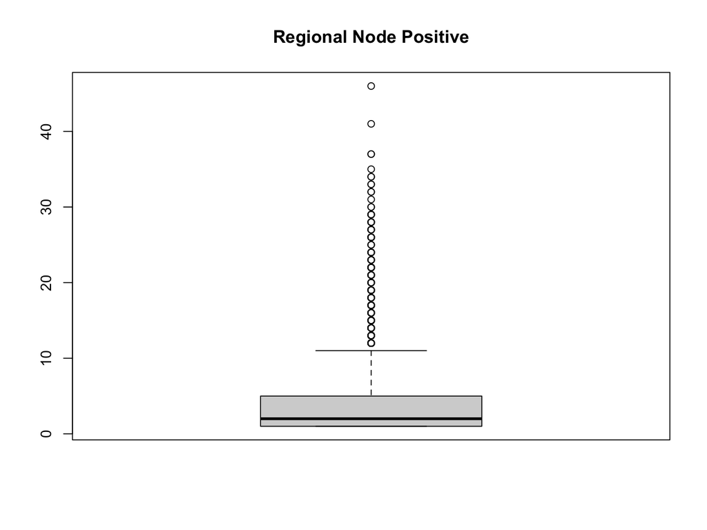

```r
boxplot(clean_data$regional_node_positive, main = "Regional Node Positive")
```

14. Regional Node Positive: The box plot for ‘Regional Node Positive’ indicates a distribution with a large number of outliers on the upper end, reflecting that while most patients have a relatively low number of positive regional nodes, there are several patients with a significantly higher count. Given the right skewness and the presence of many outliers, a log transformation could be appropriate to reduce the skewness and diminish the influence of outliers.